# Week 5

Kai Lukowiak

2017-10-28

Loading packages

```r
library(dplyr)
```

# Answer Questions:

## Working backwards, Part II.

A 90% confidence interval for a population mean is (65, 77). The population distribution is approximately normal and the population standard deviation is unknown. This confidence interval is based on a simple random sample of 25 observations. Calculate the sample mean, the margin of error, and the sample standard deviation.

```r
n <- 25
me <- (77-65)/2
xbar <- me+ 65
tVal <- qt(.95, n-1)
# me = t*sd/sqrt(n)
sd <- sqrt(n)*me/tVal
```

The sample mean is `71`, the sample margin of error is `6`, and the sample standard deviation is `17.53`

## 5.20 High School and Beyond, Part I.

### (b) Are the reading and writing scores of each student independent of each other?

I would guess that the two samples are not independent because one students reading would impact the same students writing. We can assume that they are independent between students.

### (c) Create hypotheses appropriate for the following research question: is there an evident difference in the average scores of students in the reading and writing exam?

$$H_o:\mu_r-\mu_w = 0$$
$$H_a:\mu_r-\mu_w \ne 0$$

### (d) Check the conditions required to complete this test.

The conditions required to perform the hypothesis test are independence and normalcy.

1. Independence
- Because they are paired they are not independent.
2. Normally distributed
- They do look normally distributed. It is still possible to do a t test on these.

### (e) The average observed difference in scores is $\bar x_{read} − \bar x_{write} = −0.545$ , and the standard deviation of the differences is 8.887 points. Do these data provide convincing evidence of a difference between the average scores on the two exams?

```r
sd <- 8.887
xbar <- 0.545
tVal <- xbar/sd
n <- 200
p <- pt(tVal, n-1)
```

### (f) What type of error might we have made? Explain what the error means in the context of the application.

There are two types of error:

1. Type 1 error: *Reject the null when the true value is not actually different.
2. Type 2 error: *Do not reject the null when there is a difference between the means.

Since we did not reject the null, we might be suffering from Type 2 error.

### (g) Based on the results of this hypothesis test, would you expect a confidence interval for the average difference between the reading and writing scores to include 0? Explain your reasoning.

Yes, because we tested whethere or not the means were different from each other, to reject the null would require the 95% CI to not include zero, because we did not reject the null, we know that the 95% CI does include zero.

## 5.32 Fuel efficiency of manual and automatic cars, Part I.

Each year the US Environmental Protection Agency (EPA) releases fuel economy data on cars manufactured in that year. Below are summary statistics on fuel efficiency (in miles/gallon) from random samples of cars with manual and automatic transmissions manufactured in 2012. Do these data provide strong evidence of a difference between the average fuel efficiency of cars with manual and automatic transmissions in terms of their average city mileage? Assume that conditions for inference are satisfied.

Loading the data:

```r
manualMean <- 19.85
manualSD <- 4.51
autoMean <- 16.12
autoSD <- 3.58
n <- 26
```

Degrees of freedom:

```r
degF <- (autoSD**2/n + manualSD**2/n)**2 / ((autoSD**2/n)**2/(n-1) + (manualSD**2/n)**2/(n-1))
```

The ttest:

```r
se <- sqrt(autoSD**2/n + manualSD**2/n)

t = (autoMean - manualMean)/se
pt(t, degF )
```

```
## [1] 0.00091087
```

## 5.48 Work hours and education.

The General Social Survey collects data on demographics, education, and work, among many other characteristics of US residents.47 Using ANOVA, we can consider educational attainment levels for all 1,172 respondents at once. Below are the distributions of hours worked by educational attainment and relevant summary statistics that will be helpful in carrying out this analysis.

### (a) Write hypotheses for evaluating whether the average number of hours worked varies across the five groups.

$$H_O: \mu_l=\mu_{hs}=\mu_{Jr Col}=\mu_{barhalors}=\mu_{grad}$$
$$H_a: \exists \mu_i \ne \mu_j$$

### (c) Below is part of the output associated with this test. Fill in the empty cells.

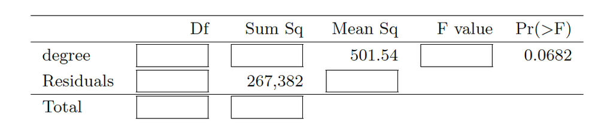

```r
xbar <- c(38.67, 39.6, 41.39, 42.55, 40.85)
sd <- c(15.81, 14.97, 18.1, 13.62, 15.51)
n <- c(121, 546, 97, 253, 155)
df <- data.frame (xbar, sd, n)
df %>% knitr::kable()
```

| xbar | sd | n |
| --- | --- | --- |
| 38.67 | 15.81 | 121 |
| 39.60 | 14.97 | 546 |
| 41.39 | 18.10 | 97 |
| 42.55 | 13.62 | 253 |
| 40.85 | 15.51 | 155 |

```r
n <- sum(df$n)
k <- nrow(df)
degFre <- n - k - 1
res <- n - k

fStat <- qf(1 - 0.0682, degFre, res)

MSE <- 501.54/fStat

SSD <- degFre * 501.54
SSE <- 267382 # Ambiguous naming.
SST <- SSD + SSE
```

[output not shown]